# IELTS 考生构成与成绩 探索性可视化

TidyTuesday · 2026-08-18 (Week 33)

作者

zlZayn

发布于

2026年9月20日

# 两科的差距全在听力与阅读，说写几乎重合

本周五个 CSV 都是**已聚合的比例与均分**：没有一行是一个人，也没有任何一个候选人数。所以全篇只回答三件事——分数在**档位构成**上长什么样、Academic 与 General Training 差在哪、**报考理由**比考试类型能不能分得更开。

本页所有图只用两种类别色，含义固定、不换位：**砖红 = Academic**、**芥黄 = General Training**。同一场考试在文字、表头与图例里保持同一个名字与同一个颜色，跨图可直接对照。

## 口径：`percent` 是组内构成，不是人数

1. **`percent` 的分母**：每个 `(type, 实体, year)` 组内 12 档的 `percent` 合计恒为 1（实测 0.98–1.02，偏差来自四舍五入）。所以 `percent` 是**该语言／国籍／理由自身在该学年的档位构成**，不是全体考生的占比：跨语言相加没有意义，也不能用来说”某语言考生更多”。
2. **行粒度**：五个文件分别是 2880 / 2832 / 792 / 1200 / 1180 行，键为 `type × 实体 × year`（构成表再加 12 档，成绩表再加 5 个 `part`）。53 个 first language、58 个 nationality、11 个报考理由、3 个学年、2 个 `type`。
3. **构成表与成绩表是同一批键**：language 侧 240 个键、nationality 侧 236 个键，两个文件之间的键集**逐一相同**（已逐一比对，两侧完全一致）。这解释了”1200 ≠ 53×5×2×3”的缺口：不是成绩缺列，而是 318 个可能的 `type × language × year` 组合里只有 240 个被报告——每年每科各 40 个语言，三年间共出现 53 个标签（差额来自跨年增删与改拼写，见最后一节）。
4. **`score` 量纲是雅思 9 分制**：language 侧 4.27–8.15，nationality 侧 4.24–8.73。成绩表里 `overall` **不是**四科均值的再聚合（最大偏离 0.150，中位 0.063）——所以图 1 把 `overall` 单列一排，不当派生量。

## 图 1 ｜ 差距只在输入型技能

[figure not shown]

图 1: The Academic / General Training gap lives in the two receptive skills; speaking and writing are effectively identical.

**读数**（每点 = 120 个 language-year 格子的未加权均值；两个类型的格子数相同）：

图 1 的原始数字（与图同源；正文引用的值必须与此表一致）：

表 1: 图 1 的原始数字（9 分制均分；差值 = Academic − General Training；后三列是同口径的逐年差值）

| 技能 | Academic | General Training | 差值 | 2022-2023 | 2023-2024 | 2024-2025 |
| --- | --- | --- | --- | --- | --- | --- |
| Reading | 6.545 | 6.015 | +0.530 | +0.515 | +0.671 | +0.404 |
| Listening | 6.646 | 6.167 | +0.479 | +0.375 | +0.487 | +0.574 |
| Overall | 6.472 | 6.202 | +0.270 | +0.230 | +0.325 | +0.256 |
| Speaking | 6.396 | 6.357 | +0.039 | +0.010 | +0.086 | +0.022 |
| Writing | 6.050 | 6.027 | +0.023 | -0.005 | +0.052 | +0.022 |

逐年看，两科的排序在三个学年里换过一次位：Reading 的差值 +0.515 → +0.671 → +0.404，而 Listening 是 +0.375 → +0.487 → +0.574：最近一个学年是 Listening 领先。Writing 在 2022-2023 出现过**负值** -0.005，即 General Training 略高于 Academic——所以”说写两科重合”是稳定结论，“哪一科差距最大”不是。

## 图 2 ｜ 高分组是整段右移，不是少数人拉高

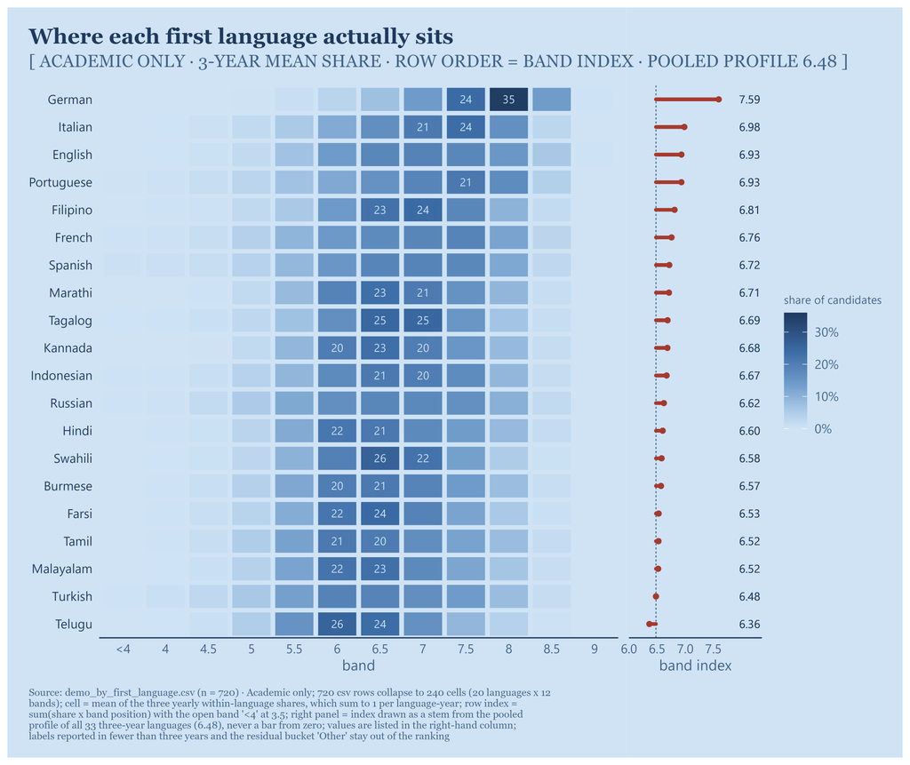

图 2: Three-year band composition by first language: the top of the roster is not a spike at the ceiling, it is the whole profile shifted right.

raw 2880 -> plotted 720 (仅 Academic（另一个 type 的 1440 行整体剔除）; 只保留三个学年都出现的语言（剔除 252 行单年/双年标签）; 残差桶 Other 不参与排名（候选池 33 个 -> 排名池 32 个）; 按指数取排名池前 20 个（剔除 12 个）)。**图 2 选 first language 而不是 nationality**：language 侧构成表与成绩表的键完全对齐（都是 240 个键），图 1 也用同一维度，两图共用同一批键；nationality 侧只有 236 个键、键集不同，还多一对跨年改写的标签（Hong Kong / Iran），换维度会让三张图的样本口径对不上。每条名册行 = 该语言三个学年档位份额的算术平均（**不是**按考生人数加权，数据里没有人数）；左侧格子里的数字是份额（≥20% 才标注），右侧棒是从**所有 33 个三年齐备语言的合并剖面**（指数 6.48）拉出来的偏差，不是从 0 起画的柱。

- 合并剖面本身非常窄：81.2% 的份额落在 5.5–7.5 之间，39.0% 在 7 分及以上，5.5 以下只有 9.0%。跨语言比较的始终是”每个语言自己的构成”，不是”多少人”。
- 头部不是天花板上的尖峰：German 指数 7.59，峰值在 8 档（35.3%），7 分及以上合计 87.5%，而 5.5 以下只有 0.27%——整段右移。名册末位 Telugu 的 7 分及以上份额仍有 29.5%。
- 名册是按**指数**截取的前 20 个（指数 7.59 – 6.36），不是”考生最多的 20 个”：数据里没有任何人数，任何前 N 都只能按结果统计量选。这个口径在图注与下表里都写明。

表 2: 图 2 的原始数字（Academic，三个学年的档位份额平均；与热图同一份聚合）

| 语言 | 档位指数 | 峰值档位 | 峰值份额 | 7 分及以上 | 5.5 以下 |
| --- | --- | --- | --- | --- | --- |
| German | 7.594 | 8 | 35.3% | 87.5% | 0.3% |
| Italian | 6.983 | 7.5 | 23.6% | 63.7% | 2.8% |
| English | 6.932 | 7 | 19.1% | 58.0% | 2.9% |
| Portuguese | 6.931 | 7.5 | 21.3% | 61.0% | 4.9% |
| Filipino | 6.810 | 7 | 24.0% | 53.8% | 3.0% |
| French | 6.756 | 7.5 | 18.7% | 52.4% | 6.1% |
| Spanish | 6.716 | 7 | 18.8% | 51.0% | 6.5% |
| Marathi | 6.710 | 6.5 | 23.2% | 47.0% | 2.3% |
| Tagalog | 6.686 | 7 | 24.8% | 47.8% | 3.6% |
| Kannada | 6.682 | 6.5 | 23.2% | 45.2% | 2.3% |
| Indonesian | 6.668 | 6.5 | 20.8% | 47.6% | 5.2% |
| Russian | 6.620 | 6.5 | 18.1% | 46.3% | 7.6% |
| Hindi | 6.599 | 6 | 21.6% | 41.6% | 4.2% |
| Swahili | 6.579 | 6.5 | 26.1% | 41.5% | 3.7% |
| Burmese | 6.569 | 6.5 | 21.0% | 41.7% | 5.4% |
| Farsi | 6.527 | 6.5 | 24.2% | 38.2% | 4.9% |
| Tamil | 6.524 | 6 | 21.0% | 39.0% | 6.4% |
| Malayalam | 6.519 | 6.5 | 23.0% | 37.5% | 4.9% |
| Turkish | 6.480 | 6 | 19.0% | 40.1% | 9.5% |
| Telugu | 6.362 | 6 | 25.7% | 29.5% | 5.8% |

表 3: 图 2 的合并剖面：33 个三年齐备语言的档位份额平均（份额不含任何名义值；累计列自低档向上累加）

| 档位 | 份额 | 累计份额 |
| --- | --- | --- |
| <4 | 0.32% | 0.3% |
| 4 | 0.70% | 1.0% |
| 4.5 | 2.14% | 3.2% |
| 5 | 5.87% | 9.0% |
| 5.5 | 13.09% | 22.1% |
| 6 | 19.44% | 41.6% |
| 6.5 | 19.44% | 61.0% |
| 7 | 16.49% | 77.5% |
| 7.5 | 12.77% | 90.3% |
| 8 | 7.89% | 98.2% |
| 8.5 | 1.82% | 100.0% |
| 9 | 0.02% | 100.0% |

## 图 3 ｜ 报考理由的分化比考试类型更宽

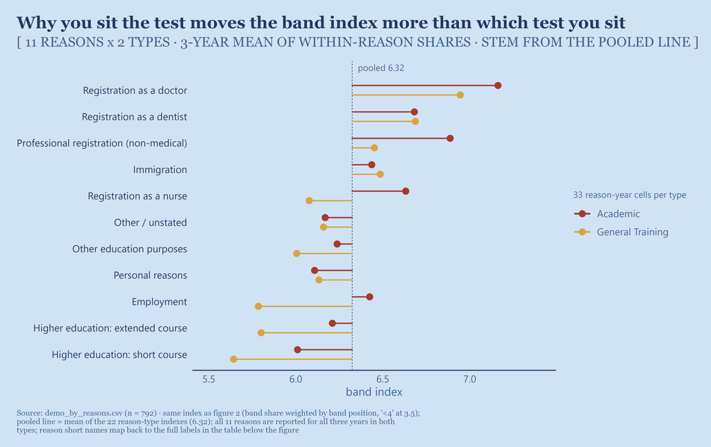

图 3: Purpose of taking the test separates candidates more than test type does: the spread across the 11 reasons is far wider than the Academic / General Training gap in speaking and writing.

**读数**：

- 同一个口径下，**理由内部的跨度比两科之差更大**：Academic 的 11 个理由指数从 6.01（Higher education: short course）到 7.16（Registration as a doctor），跨度 1.15；General Training 从 5.64 到 6.95，跨度 1.30。对比图 1 里 Speaking / Writing 的 0.039 / 0.023，不是一个量级。
- 高的一头是**执业注册类**：doctor 7.16、dentist 6.68、nurse 6.63（均为 Academic）；低的一头是短期高等教育与个人原因。这个头尾顺序在三个学年里没有换过位，唯一的例外是 Immigration：三年里上移 0.199，中途与 Employment 换过一次位（逐年见下表）。
- 两科的差值在理由维度上**时正时负**：正得最多的是 Employment +0.64，接近零甚至反向的是 Immigration -0.05、Registration as a dentist -0.01 与 Personal reasons -0.03。所以”Academic 比 General Training 高”只在部分理由上成立。

表 4: 图 3 的原始数字（档位指数；短名 → 全名的映射在此可查）

| 理由（数据原值） | 图内短名 | Academic | General Training | 差值 |
| --- | --- | --- | --- | --- |
| For registration as a doctor | Registration as a doctor | 7.162 | 6.945 | +0.216 |
| For professional registration (NOT medical) | Professional registration (non-medical) | 6.887 | 6.451 | +0.436 |
| For registration as a dentist | Registration as a dentist | 6.681 | 6.687 | -0.006 |
| For registration as a nurse (including CGFNS) | Registration as a nurse | 6.632 | 6.077 | +0.555 |
| For immigration | Immigration | 6.436 | 6.485 | -0.049 |
| For employment | Employment | 6.424 | 5.785 | +0.640 |
| For other education purposes | Other education purposes | 6.237 | 6.004 | +0.233 |
| For higher education extended course (three months or more) | Higher education: extended course | 6.210 | 5.800 | +0.410 |
| (Other) | Other / unstated | 6.169 | 6.159 | +0.009 |
| For personal reasons | Personal reasons | 6.108 | 6.133 | -0.025 |
| For higher education short course (three months or less) | Higher education: short course | 6.010 | 5.642 | +0.368 |

表 5: Academic 每个理由的档位指数逐年：头尾（Registration as a doctor / Higher education: short course）三年没换位；单条最大移动是 Immigration 的 0.199，其余都 ≤ 0.091

| 理由 | 2022-2023 | 2023-2024 | 2024-2025 | 三年极差 |
| --- | --- | --- | --- | --- |
| Registration as a doctor | 7.212 | 7.138 | 7.136 | 0.076 |
| Professional registration (non-medical) | 6.919 | 6.875 | 6.867 | 0.053 |
| Registration as a dentist | 6.702 | 6.689 | 6.653 | 0.049 |
| Registration as a nurse | 6.644 | 6.633 | 6.618 | 0.026 |
| Immigration | 6.358 | 6.396 | 6.557 | 0.199 |
| Employment | 6.401 | 6.416 | 6.457 | 0.056 |
| Other education purposes | 6.212 | 6.229 | 6.270 | 0.058 |
| Higher education: extended course | 6.268 | 6.176 | 6.187 | 0.091 |
| Other / unstated | 6.135 | 6.203 | 6.169 | 0.068 |
| Personal reasons | 6.134 | 6.095 | 6.094 | 0.039 |
| Higher education: short course | 5.979 | 5.993 | 6.057 | 0.077 |

## 数据异常（只报不改）

| 异常 | 实测 | 处置 |
| --- | --- | --- |
| `percent` 组内合计有 1–3 个百分点漂移 | language 0.98–1.02、nationality 0.97–1.03、reason 0.97–1.02 | 判定为四舍五入，不改数据；图 2 的行指数按组内实际合计归一 |
| 53 个 first language 但每年每科只有 40 个 | 318 个 `type × language × year` 组合里缺 78 个（nationality 侧 348 里缺 112 个），且构成表与成绩表**缺的是同一组**（键集逐一相同） | 缺的是整组合，不是缺列；图 2 只取三年齐备的语言（raw 2880 -> plotted 720 (仅 Academic（另一个 type 的 1440 行整体剔除）; 只保留三个学年都出现的语言（剔除 252 行单年/双年标签）; 残差桶 Other 不参与排名（候选池 33 个 -> 排名池 32 个）; 按指数取排名池前 20 个（剔除 12 个）)） |
| 同一实体跨年换拼写 | first_language：Gujurati（2022-2023）→ Gujarati（2023-2024,2024-2025）；first_language：Ibo/lgbo（2022-2023）→ Ibo/Igbo（2023-2024,2024-2025）；first_language：Singhalese（2022-2023）→ Sinhalese（2023-2024,2024-2025）… | 不合并、不改标签；这些标签因此天然被”三年齐备”筛掉，不会在热图里被拆成两行 |
| 近似但**不是**改名 | Dari / Farsi；Algeria / Nigeria；Chile / China；China / Ghana；Iran / Oman | 一律不合并。Dari 只在 2024-2025 出现且与 Farsi 同年并存 → 是新增标签，不是 Farsi 的改写；Chile / China、China / Ghana、Algeria / Nigeria、Iran / Oman 只是编辑距离 ≤ 2 的巧合，同年并存，与改名无关 |
| `overall` 不是四科均值的再聚合 | language 侧最大偏离 0.150（中位 0.063），nationality 侧 0.125 | 图 1 把 `overall` 单列，不当派生量；不重算 |
| 两个成绩文件的极值不同量级 | language 侧最高 8.148（Academic · German · reading），nationality 侧最高 8.727（General Training · United States of America · speaking） | 两个维度是不同粒度的切分，本报告不做跨维度比较 |
| 报考理由的 `percent` 也是档位构成 | 每个 `type × reason × year` 内 12 档合计 1（66 组），11 个理由各自合计 1、总和 = 11 —— **不是**”选该理由的人数占比” | 图 3 只用档位指数，不从该文件推断理由的人气排序 |

表 6: 标签近似对：编辑距离 ≤ 2 或前缀关系；只有年份不相交才判定为跨年改名

| 数据集 | 标签A | 标签B | 编辑距离 | A出现 | B出现 | 判断 |
| --- | --- | --- | --- | --- | --- | --- |
| first_language | Dari | Farsi | 2 | 2024-2025 | 2022-2023,2023-2024,2024-2025 | 同年并存，不是改名 |
| first_language | Gujarati | Gujurati | 1 | 2023-2024,2024-2025 | 2022-2023 | 跨年改名（年份不相交） |
| first_language | Ibo/Igbo | Ibo/lgbo | 1 | 2023-2024,2024-2025 | 2022-2023 | 跨年改名（年份不相交） |
| first_language | Singhalese | Sinhalese | 1 | 2022-2023 | 2023-2024,2024-2025 | 跨年改名（年份不相交） |
| nationality | Algeria | Nigeria | 2 | 2024-2025 | 2022-2023,2023-2024,2024-2025 | 同年并存，不是改名 |
| nationality | Chile | China | 2 | 2022-2023,2023-2024,2024-2025 | 2022-2023,2023-2024,2024-2025 | 同年并存，不是改名 |
| nationality | China | Ghana | 2 | 2022-2023,2023-2024,2024-2025 | 2022-2023,2023-2024,2024-2025 | 同年并存，不是改名 |
| nationality | Hong Kong | Hong Kong, SAR of China | 14 | 2023-2024,2024-2025 | 2022-2023 | 跨年改名（年份不相交） |
| nationality | Iran | Iran, Islamic Republic of | 21 | 2022-2023 | 2023-2024,2024-2025 | 跨年改名（年份不相交） |
| nationality | Iran | Oman | 2 | 2022-2023 | 2022-2023,2023-2024,2024-2025 | 同年并存，不是改名 |

## 方法与口径

| 项 | 值 |
| --- | --- |
| 数据 | `data/demo_by_first_language.csv`（2880 × 5）、`demo_by_nationality.csv`（2832 × 5）、`demo_by_reasons.csv`（792 × 5）、`performance_by_first_language.csv`（1200 × 5）、`performance_by_nationality.csv`（1180 × 5） |
| 图 1 样本 | `performance_by_first_language.csv` 全量 1200 行，无剔除；每个 `type × part` 折成 1 个均值，共 10 个点 |
| 图 2 样本 | raw 2880 -> plotted 720 (仅 Academic（另一个 type 的 1440 行整体剔除）; 只保留三个学年都出现的语言（剔除 252 行单年/双年标签）; 残差桶 Other 不参与排名（候选池 33 个 -> 排名池 32 个）; 按指数取排名池前 20 个（剔除 12 个）) |
| 图 3 样本 | `demo_by_reasons.csv` 全量 792 行，无剔除；22 个”理由 × 类型”指数 |
| 全篇共同口径 | 均值一律是**格子均值**（language-year / reason-year 格子等权），因为五个文件里没有任何候选人数；`percent` 一律读作组内档位构成 |
| 档位指数 | `sum(份额 × 档位位置)`，档位位置取 `<4 → 3.5`、`4 → 4` … `9 → 9`；`<4` 是开区间，只能给名义值，故指数是**名册内的排序刻度**，不是雅思官方分 |
| 不画的东西 | 饼图、双 Y 轴、从 0 起画的截断柱、考生人数（数据里没有）、跨维度（语言 ↔︎ 国籍）比较 |